# Variation in the FACE, PRICE and GOAT diphthongs in the adolescent data

## 3.3 z-score the continuous variables

```r
data_new_new <- map(data_new_new,
            ~ mutate(.x,
                     normF1_20z = scale(normF1_20, center = TRUE),
              normF2_20z = scale(normF2_20, center = TRUE),
              LogDurZ = scale(LogDur, center = TRUE),
              LogTLz = scale(LogTL, center = TRUE),
            ))
```

Plot these to check it worked:

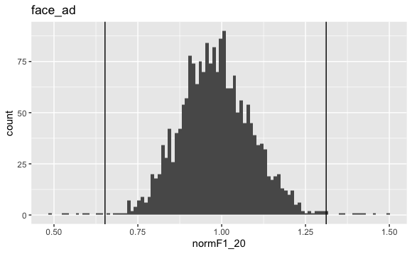

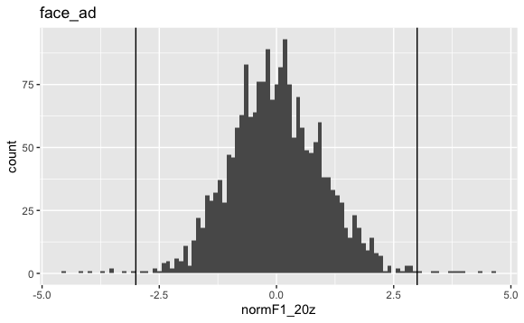

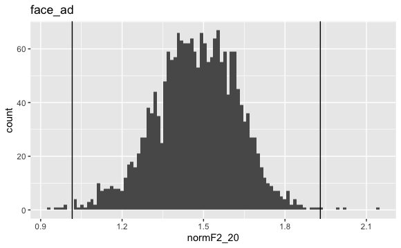

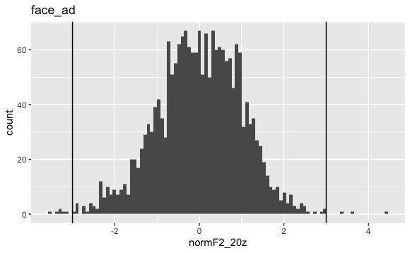

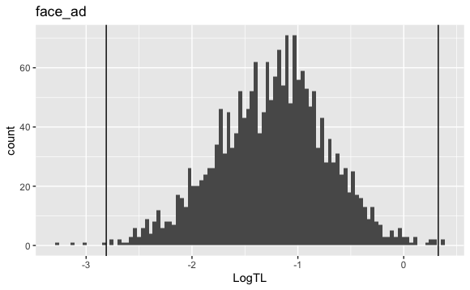

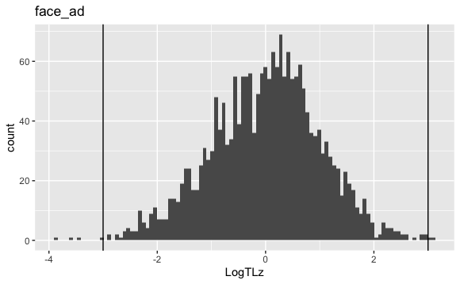

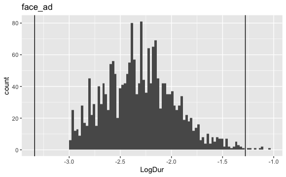

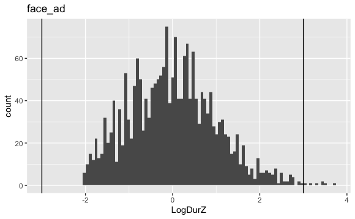

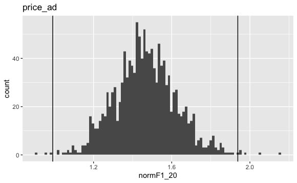

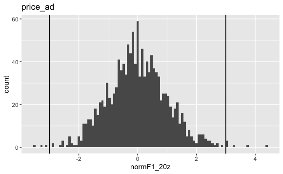

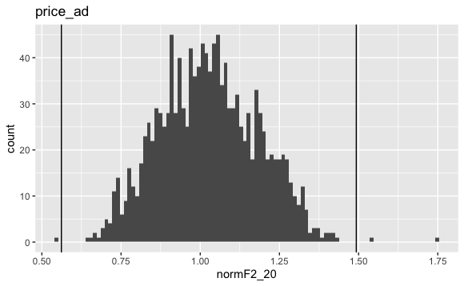

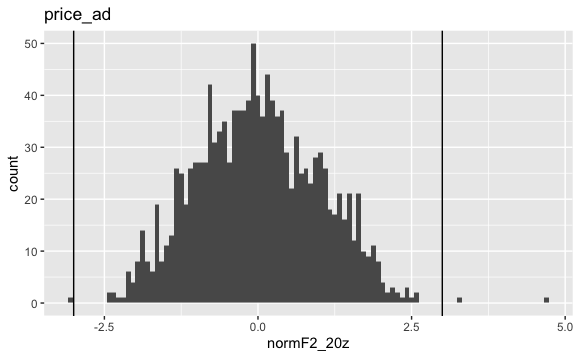

[20 more figures not shown]

```r
# Z-scored variables and their originals
z_vars <- c("normF1_20",
          "normF1_20z",
          "normF2_20",
          "normF2_20z",
          "LogTL",
          "LogTLz",
          "LogDur",
          "LogDurZ")

# Names of dataframes
data_names <- names(data_new_new)

for(i in data_names){
  for(v in z_vars){
 print(
  ggplot(data_new_new[[i]], aes(get(v))) +
      geom_histogram(bins=100) +
    xlab(v)+ggtitle(paste(i)) +
    geom_vline(xintercept = mean( data_new_new[[i]][[v]] ) - 3*sd(data_new_new[[i]][[v]])) +
    geom_vline(xintercept = mean( data_new_new[[i]][[v]] ) + 3*sd(data_new_new[[i]][[v]]))
  )
    }}
```

Looks good.

## 3.4 Run the models: onset F1 / F2

Models with:

- CofP
- outcode
- sex

… to see which is the best predictor.

### 3.4.1 FACE

```r
set.seed(8)

# CofP
#face_ad_f1_m_CofP <- brm(normF1_20z ~ LogDurZ +
 #                      CofP*prec.seg +
  #                         CofP*following +
   #                      CofP*task +
    #                   (1 + prec.seg + following + task| participant) +
     #                (1+ CofP|word), data = data_new_new$face_ad,
      #               prior = my_priors,
       #              control = list(adapt_delta = 0.99),
        #             sample_prior=TRUE,
         #   file="models/face_ad_f1_m_CofP")

# outcode
#face_ad_f1_m_outcode <- brm(normF1_20z ~ LogDurZ +
 #                      outcode*prec.seg +
  #                         outcode*following +
   #                      outcode*task +
    #                   (1 + prec.seg + following + task| participant) +
     #                (1+ outcode|word), data = data_new_new$face_ad,
      #               prior = my_priors,
       #              control = list(adapt_delta = 0.99),
        #             sample_prior=TRUE,
         #   file="models/face_ad_f1_m_outcode")

# Sex
#face_ad_f1_m_sex <- brm(normF1_20z ~ LogDurZ +
 #                      sex*prec.seg +
  #                         sex*following +
   #                      sex*task +
    #                   (1 + prec.seg + following + task| participant) +
     #                (1+ sex|word), data = data_new_new$face_ad,
      #               prior = my_priors,
       #              control = list(adapt_delta = 0.99),
        #             sample_prior=TRUE,
         #   file="models/face_ad_f1_m_sex")

# None of the above
#face_ad_f1_m_none <- brm(normF1_20z ~ LogDurZ +
 #                      prec.seg +
  #                         following +
   #                      task +
    #                   (1 + prec.seg + following + task| participant) +
     #                (1|word), data = data_new_new$face_ad,
      #               prior = my_priors,
       #              control = list(adapt_delta = 0.99),
        #             sample_prior=TRUE,
         #   file="models/face_ad_f1_m_none")
```

### 3.4.2 PRICE

**This code has been commented out to stop me accidentally rerunning the models when I click “Run all / Run all chunks above”**

```r
set.seed(56)

# CofP
#price_ad_f2_m_CofP <- brm(normF2_20z ~ LogDurZ +
  #                     CofP*prec.seg +
   #                        CofP*following +
    #                     CofP*task +
     #                  (1 + prec.seg + following + task| participant) +
      #               (1+ CofP|word), data = data$price,
       #              prior = my_priors3,
        #             control = list(adapt_delta = 0.99),
         #            sample_prior=TRUE,
          #  file="models/price_ad_f2_m_CofP")

# outcode
#price_ad_f2_m_outcode <- brm(normF2_20z ~ LogDurZ +
 #                      outcode*prec.seg +
  #                         outcode*following +
   #                      outcode*task +
    #                   (1 + prec.seg + following + task| participant) +
     #                (1+ outcode|word), data = data$price,
      #               prior = my_priors3,
       #              control = list(adapt_delta = 0.99),
        #             sample_prior=TRUE,
         #   file="models/price_ad_f2_m_outcode")

# Sex
#price_ad_f2_m_sex <- brm(normF2_20z ~ LogDurZ +
 #                      sex*prec.seg +
  #                         sex*following +
   #                      sex*task +
    #                   (1 + prec.seg + following + task| participant) +
     #                (1+ sex|word), data = data$price,
      #               prior = my_priors3,
       #              control = list(adapt_delta = 0.99),
        #             sample_prior=TRUE,
         #   file="models/price_ad_f2_m_sex")

# None of the above
#price_ad_f2_m_none <- brm(normF2_20z ~ LogDurZ +
 #                      prec.seg +
  #                         following +
   #                      task +
    #                   (1 + prec.seg + following + task| participant) +
     #                (1|word), data = data_new_new$price_ad,
      #               prior = my_priors,
       #              control = list(adapt_delta = 0.99),
        #             sample_prior=TRUE,
         #   file="models/price_ad_f2_m_none")
```

### 3.4.3 GOAT

```r
set.seed(21)

# CofP
#goat_ad_f2_m_CofP <- brm(normF2_20z ~ LogDurZ +
 #                      CofP*prec.seg +
  #                        CofP*following +
   #                      CofP*task +
    #                   (1 + prec.seg + following + task| participant) +
     #                (1+ CofP|word), data = data_new_new$goat_ad,
      #               prior = my_priors,
       #              control = list(adapt_delta = 0.99),
        #             sample_prior=TRUE,
         #   file="models/goat_ad_f2_m_CofP")

# outcode
#goat_ad_f2_m_outcode <- brm(normF2_20z ~ LogDurZ +
 #                      outcode*prec.seg +
  #                         outcode*following +
   #                      outcode*task +
    #                   (1 + prec.seg + following + task| participant) +
     #                (1+ outcode|word), data = data_new_new$goat_ad,
      #               prior = my_priors,
       #              control = list(adapt_delta = 0.99),
        #            sample_prior=TRUE,
         #   file="models/goat_ad_f2_m_outcode")

# Sex
#goat_ad_f2_m_sex <- brm(normF2_20z ~ LogDurZ +
 #                      sex*prec.seg +
  #                         sex*following +
   #                      sex*task +
    #                   (1 + prec.seg + following + task| participant) +
     #                (1+ sex|word), data = data_new_new$goat_ad,
      #               prior = my_priors,
       #              control = list(adapt_delta = 0.99),
        #             sample_prior=TRUE,
         #   file="models/goat_ad_f2_m_sex")

# None of the above
#goat_ad_f2_m_none <- brm(normF2_20z ~ LogDurZ +
 #                      prec.seg +
  #                         following +
   #                      task +
    #                   (1 + prec.seg + following + task| participant) +
     #                (1|word), data = data_new_new$goat_ad,
      #               prior = my_priors,
       #              control = list(adapt_delta = 0.99),
        #             sample_prior=TRUE,
         #   file="models/goat_ad_f2_m_none")
```

### 3.4.4 *Like*

Get rid of task for the *like* models:

```r
table(data_new_new$price_ad$task)
```

```
interview   reading
     1211        94
```

```r
lapply(data, nrow)
```

```
$face_ad
[1] 2025

$goat_ad
[1] 1920

$price_ad
[1] 1312

$like_ad
[1] 1057
```

```r
data$like <- data$like %>% filter(task=="interview")

lapply(data, nrow)
```

```
$face_ad
[1] 2025

$goat_ad
[1] 1920

$price_ad
[1] 1312

$like_ad
[1] 1057

$like
[1] 1052
```

Try “get prior”

```r
get_prior(normF2_20z ~ LogDurZ +
                         CofP +
                       (1 | participant),
                       data = data$like)
```

```
Error: The following variables are missing in 'data':
'normF2_20z', 'LogDurZ'
```

Set priors for “like”:

## 3.5 Run the models: Trajectory Length

Check distribution of Trajectory Length

```r
map(data,
    ~ ggplot(.x, aes(x=norm_TL))+geom_histogram(bins=100)
    )
#ggplot(data$price, aes(x=norm_TL))+geom_histogram(bins=100)
#ggplot(data$like, aes(x=norm_TL))+geom_histogram(bins=100)
```

Log-transform the dependent variable:

```r
data <- map(data,
            ~ mutate(.x,
                     LogTL = log(norm_TL)))
```

Check the distribution of this new variable:

```r
map(data,
    ~ ggplot(.x, aes(x=LogTL))+geom_histogram(bins=100)
    )
```

Vector of predictor variables:

```r
predictors <- c("CofP",
                "outcode",
                "sex",
                "prec.seg",
                "task",
                "following")
```

Check that the contrasts for each variable are OK:

```r
map(data$price[,predictors], contrasts)
map(data$like[,c("CofP",
                "outcode",
                "sex")], contrasts)
```

Great.

Z-score the continuous variables:

```r
data <- map(data,
            ~ mutate(.x,
                     LogTLz = scale(LogTL, center = TRUE),
    LogDurZ = scale(LogDur, center = TRUE)))
```

Check the distribution of each of these to see that it worked:

```r
vars <- c("norm_TL",
          "LogTL",
          "LogTLz",
          "duration",
          "LogDur", "LogDurZ")

for(i in vars){
  print(
  ggplot(data$price, aes(x=get(i)))+geom_histogram(bins=100)+theme_minimal() +
    #geom_vline(xintercept=2) +
    #geom_vline(xintercept=-2) +
    xlab(i)
  )
}

for(i in vars){
  print(
  ggplot(data$like, aes(x=get(i)))+geom_histogram(bins=100)+theme_minimal() +
    #geom_vline(xintercept=2) +
    #geom_vline(xintercept=-2) +
    xlab(i)
  )
}
```

```r
table(data$price$participant,data$price$task)
```

Run the modelsfor PRICE Trajectory Length: **This code has been commented out to stop me accidentally rerunning the models when I click “Run all / Run all chunks above”**

```r
set.seed(48)

# CofP
#price_ad_tl_m_CofP <- brm(LogTLz ~ LogDurZ +
 #                      CofP*prec.seg +
  #                         CofP*following +
   #                      CofP*task +
    #                   (1 + prec.seg + following + task| participant) +
     #                (1+ CofP|word), data = data$price,
      #               prior = my_priors3,
       #              control = list(adapt_delta = 0.99),
        #             sample_prior=TRUE,
         #   file="models/price_ad_tl_m_CofP")

# outcode
#price_ad_tl_m_outcode <- brm(LogTLz ~ LogDurZ +
 #                      outcode*prec.seg +
  #                         outcode*following +
   #                      outcode*task +
    #                   (1 + prec.seg + following + task| participant) +
     #                (1+ outcode|word), data = data$price,
      #               prior = my_priors3,
       #              control = list(adapt_delta = 0.99),
        #             sample_prior=TRUE,
         #   file="models/price_ad_tl_m_outcode")

# Sex
#price_ad_tl_m_sex <- brm(LogTLz ~ LogDurZ +
 #                      sex*prec.seg +
  #                         sex*following +
   #                      sex*task +
    #                   (1 + prec.seg + following + task| participant) +
     #                (1+ sex|word), data = data$price,
      #               prior = my_priors3,
       #              control = list(adapt_delta = 0.99),
        #             sample_prior=TRUE,
         #   file="models/price_ad_tl_m_sex")
```

And the models for *like*: **This code has been commented out to stop me accidentally rerunning the models when I click “Run all / Run all chunks above”**

```r
set.seed(16)
# CofP

#like_ad_tl_m_CofP <- brm(LogTLz ~ LogDurZ +
 #                        CofP +
  #                     (1 | participant),
   #                    data = data$like,
    #                 prior = my_priors_like,
     #                control = list(adapt_delta = 0.99),
      #               sample_prior=TRUE,
       #     file="models/like_ad_tl_m_CofP")

# outcode
#like_ad_tl_m_outcode <- brm(LogTLz ~ LogDurZ +
 #                        outcode +
  #                     (1| participant),
   #                    data = data$like,
    #                 prior = my_priors_like,
     #                control = list(adapt_delta = 0.99),
      #               sample_prior=TRUE,
       #     file="models/like_ad_tl_m_outcode")

# Sex
#like_ad_tl_m_sex <- brm(LogTLz ~ LogDurZ +
 #                        sex +
  #                     (1| participant),
   #                    data = data$like,
    #                 prior = my_priors_like,
     #                control = list(adapt_delta = 0.99),
      #               sample_prior=TRUE,
       #     file="models/like_ad_tl_m_sex")
```

### 3.5.1 Load models

```r
model_names <- list.files(path="models")

models <- list()

for(i in 1:length(model_names)){
  name = paste("models/", model_names[i], sep="")
  print(name)
  models[[model_names[i]]] <- read_rds(name)

}

#file.names <- dir(path, pattern =".rds")

#file.names
```

Check that this worked:

```r
typeof(models[[2]])
```

Give names to the brms models in the list?

```r
real_names <- list.files(path="models")

real_names2 <- str_replace(real_names, "\\.rds$", "")

names(models) <- real_names2
```

Check that this worked:

```r
names(models)
```

### 3.5.2 PP check

Create lists of models, one per dependent variable:

```r
#models_price_f2 <- list(models$price_ad_f2_m_CofP, models$price_ad_f2_m_outcode, models$price_ad_f2_m_sex)
#models_like_f2 <- list(models$like_ad_f2_m_CofP, models$like_ad_f2_m_outcode,models$like_ad_f2_m_sex)
#models_price_tl <- list(models$price_ad_tl_m_CofP, models$price_ad_tl_m_outcode, models$price_ad_tl_m_sex)
#models_like_tl <- list(models$like_ad_tl_m_CofP, models$like_ad_tl_m_outcode,models$like_ad_tl_m_sex)
#models_tl <- list(price_ad_tl_m_CofP, price_ad_tl_m_outcode, price_ad_tl_m_sex)

models_goat_f2 <- list(
  "goat_ad_f2_m_CofP" = goat_ad_f2_m_CofP,
  "goat_ad_f2_m_outcode" = goat_ad_f2_m_outcode,
  "goat_ad_f2_m_sex" = goat_ad_f2_m_sex,
  "goat_ad_f2_m_none" = goat_ad_f2_m_none
)
```

Print posterior check:

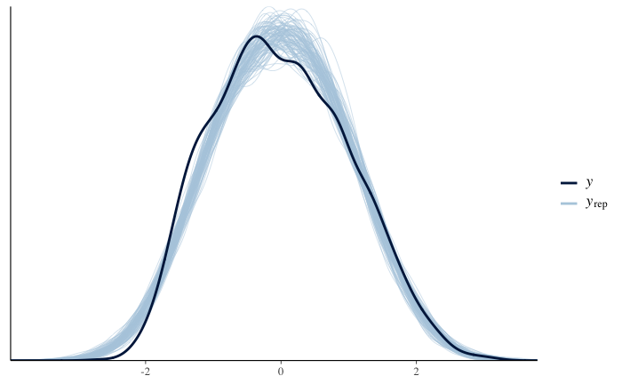

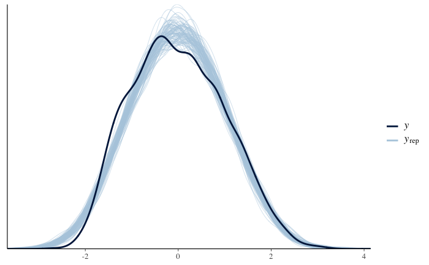

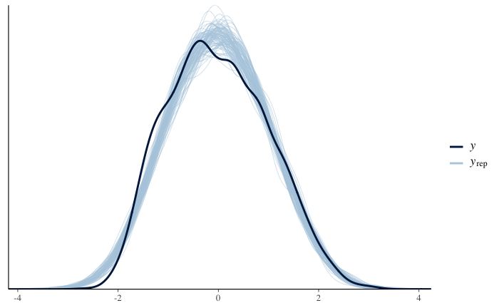

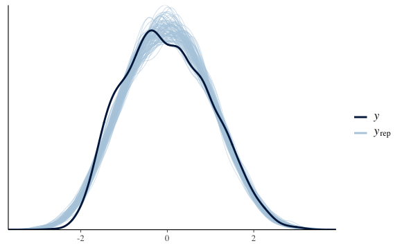

```r
lapply(models_goat_f2, pp_check, nsamples=100)
```

```r
#lapply(models_tl, pp_check, nsamples=100)
```

### 3.5.3 Select the F2 model

```r
#(price_f2_loos <- lapply(models_price_f2, loo))
#(like_f2_loos <- lapply(models_like_f2, loo))
lapply(models_goat_f2, loo)
```

[output not shown]

```
$goat_ad_f2_m_CofP

Computed from 4000 by 1906 log-likelihood matrix
```

|  | Estimate | SE |
| --- | --- | --- |
| elpd_loo | -1608.3 | 47.4 |
| p_loo | 178.1 | 11.3 |
| looic | 3216.6 | 94.9 |

```
------
Monte Carlo SE of elpd_loo is NA.

Pareto k diagnostic values:
                         Count Pct.    Min. n_eff
(-Inf, 0.5]   (good)     1866  97.9%   268
 (0.5, 0.7]   (ok)         37   1.9%   105
   (0.7, 1]   (bad)         2   0.1%   83
   (1, Inf)   (very bad)    1   0.1%   9
See help('pareto-k-diagnostic') for details.

$goat_ad_f2_m_outcode

Computed from 4000 by 1906 log-likelihood matrix
```

|  | Estimate | SE |
| --- | --- | --- |
| elpd_loo | -1617.7 | 47.9 |
| p_loo | 186.6 | 12.8 |
| looic | 3235.4 | 95.9 |

```
------
Monte Carlo SE of elpd_loo is NA.

Pareto k diagnostic values:
                         Count Pct.    Min. n_eff
(-Inf, 0.5]   (good)     1863  97.7%   430
 (0.5, 0.7]   (ok)         33   1.7%   230
   (0.7, 1]   (bad)         9   0.5%   72
   (1, Inf)   (very bad)    1   0.1%   5
See help('pareto-k-diagnostic') for details.

$goat_ad_f2_m_sex

Computed from 4000 by 1906 log-likelihood matrix
```

|  | Estimate | SE |
| --- | --- | --- |
| elpd_loo | -1604.8 | 47.2 |
| p_loo | 179.0 | 11.1 |
| looic | 3209.6 | 94.4 |

```
------
Monte Carlo SE of elpd_loo is NA.

Pareto k diagnostic values:
                         Count Pct.    Min. n_eff
(-Inf, 0.5]   (good)     1870  98.1%   362
 (0.5, 0.7]   (ok)         29   1.5%   154
   (0.7, 1]   (bad)         6   0.3%   79
   (1, Inf)   (very bad)    1   0.1%   5
See help('pareto-k-diagnostic') for details.

$goat_ad_f2_m_none

Computed from 4000 by 1906 log-likelihood matrix
```

|  | Estimate | SE |
| --- | --- | --- |
| elpd_loo | -1607.3 | 47.2 |
| p_loo | 166.7 | 10.6 |
| looic | 3214.6 | 94.3 |

```
------
Monte Carlo SE of elpd_loo is NA.

Pareto k diagnostic values:
                         Count Pct.    Min. n_eff
(-Inf, 0.5]   (good)     1882  98.7%   605
 (0.5, 0.7]   (ok)         21   1.1%   96
   (0.7, 1]   (bad)         2   0.1%   164
   (1, Inf)   (very bad)    1   0.1%   16
See help('pareto-k-diagnostic') for details.
```

```r
lapply(price_f2_loos, plot)
```

### 3.5.4 Select the TL model

```r
lapply(models_price_tl, loo)
lapply(models_like_tl, loo)
```

### 3.5.5 Create list of final models

```r
final_models <- list(price_ad_f2_m_sex= models$price_ad_f2_m_sex,
                     price_ad_tl_m_sex = models$price_ad_tl_m_sex,
                    like_ad_f2_m_CofP = models$like_ad_f2_m_CofP,
                     like_ad_f2_m_sex = models$like_ad_f2_m_sex,
                     like_ad_tl_m_CofP = models$like_ad_tl_m_CofP,
                     like_ad_tl_m_sex = models$like_ad_tl_m_sex)
```

(Keeping both “CofP” and “sex” models in for *like* because it’s not clear that either is better)

## 3.6 Model summaries

```r
lapply(final_models, parameters::model_parameters, ci=0.95, ci_method="hdi", effects="fixed")
```

# 4 Interval plots

# 5 Linguistic factors: preceding and following environment

```r
price_models <- list(models$price_ad_f2_m_sex,
                     models$price_ad_tl_m_sex)
```

Plot effects of preceding environment on the dependent vars:

```r
map(price_models,
    ~  emmeans(.x, ~ prec.seg) %>%
  gather_emmeans_draws() %>%
  ggplot(aes(x = reorder(prec.seg, .value, median), y = .value)) +
  geom_eye(.width = c(.95)) +
  stat_summary(aes(group = NA), fun.y = mean, geom = "line") +
  #facet_grid(~ sex) +
  theme_light() +
  scale_fill_manual(values = c("gray80", "skyblue")))
```

And interaction with sex:

```r
map(price_models,
    ~  emmeans(.x, ~ prec.seg | sex) %>%
  gather_emmeans_draws() %>%
  ggplot(aes(x = reorder(prec.seg, .value, median), y = .value, fill=sex)) +
  geom_eye(.width = c(.95)) +
  stat_summary(aes(group = sex), fun.y = mean, geom = "line") +
  facet_grid(~ sex) +
  theme_light() +
  scale_fill_manual(values = c("gray80", "skyblue")))
```

Plot effects of following environment on the dependent vars:

```r
map(price_models,
    ~  emmeans(.x, ~ following) %>%
  gather_emmeans_draws() %>%
  ggplot(aes(x = reorder(following, .value, median), y = .value)) +
  geom_eye(.width = c(.95)) +
  stat_summary(aes(group = NA), fun.y = mean, geom = "line") +
  #facet_grid(~ sex) +
  theme_light() +
  scale_fill_manual(values = c("gray80", "skyblue")))
```

And interaction with sex:

```r
map(price_models,
    ~  emmeans(.x, ~ following | sex) %>%
  gather_emmeans_draws() %>%
  ggplot(aes(x = reorder(following, .value, median), y = .value, fill=sex)) +
  geom_eye(.width = c(.95)) +
  stat_summary(aes(group = sex), fun.y = mean, geom = "line") +
  facet_grid(~ sex) +
  theme_light() +
  scale_fill_manual(values = c("gray80", "skyblue")))
```